# exercise-05

Jessica V

2024-03-31

```r
library(tidyverse)
```

```r
library(ggplot2)
library(dplyr)
```

# Step 1

## Here I load the “IMDB-movies.csv” dataset as a “tibble” named d

```r
f <- "https://raw.githubusercontent.com/difiore/ada-2024-datasets/main/IMDB-movies.csv"
d <- read_csv(f, col_names = TRUE)
head(d)
```

```
## # A tibble: 6 × 10
##   tconst    titleType primaryTitle startYear runtimeMinutes genres averageRating
##   <chr>     <chr>     <chr>            <dbl>          <dbl> <chr>          <dbl>
## 1 tt0002130 movie     Dante's Inf…      1911             68 Adven…           7
## 2 tt0002844 movie     Fantômas: I…      1913             54 Crime…           7
## 3 tt0003037 movie     Fantomas: T…      1913             61 Crime…           7
## 4 tt0003165 movie     Fantômas: T…      1913             90 Crime…           7
## 5 tt0003419 movie     The Student…      1913             85 Drama…           6.5
## 6 tt0003643 movie     The Avengin…      1914             78 Crime…           6.5
## # ℹ 3 more variables: numVotes <dbl>, nconst <chr>, director <chr>
```

# Step 2

Here I use a one-line statement to filter the dataset to include just movies from 1920 to 1979 and movies that are between 1 and 3 hours long (runtimeMinutes >= 60 and runtimeMinutes <= 180), and add a new column that codes the startYear into a new variable, decade (“20s”, “30s”, …“70s”).

```r
a <- d%>%
  filter(startYear >1919) %>%
  filter(startYear <1980) %>%
  filter(runtimeMinutes <=180)%>%
  filter(runtimeMinutes >=60) %>%
  mutate(decade = if_else(startYear >=2000,
                          paste0(startYear %/% 10 * 10, "'s"),
                          paste0((startYear - 1900) %/% 10 * 10, "'s")))

a
```

```
## # A tibble: 5,651 × 11
##    tconst   titleType primaryTitle startYear runtimeMinutes genres averageRating
##    <chr>    <chr>     <chr>            <dbl>          <dbl> <chr>          <dbl>
##  1 tt00103… movie     The Cabinet…      1920             76 Fanta…           8.1
##  2 tt00110… movie     Leaves From…      1920            167 Drama            6.7
##  3 tt00111… movie     Dr. Jekyll …      1920             82 Drama…           7
##  4 tt00112… movie     The Golem         1920             76 Fanta…           7.2
##  5 tt00113… movie     The Last of…      1920             73 Actio…           6.7
##  6 tt00114… movie     The Mark of…      1920            107 Adven…           7.1
##  7 tt00115… movie     The Penalty       1920             90 Crime…           7.4
##  8 tt00116… movie     The Saphead       1920             77 Comedy           6.2
##  9 tt00118… movie     Way Down Ea…      1920            145 Drama…           7.4
## 10 tt00118… movie     Why Change …      1920             90 Comed…           6.7
## # ℹ 5,641 more rows
## # ℹ 4 more variables: numVotes <dbl>, nconst <chr>, director <chr>,
## #   decade <chr>
```

# Step 3

## Here I use {ggplot2} to plot histograms of the distribution of runtimeMinutes for each decade.

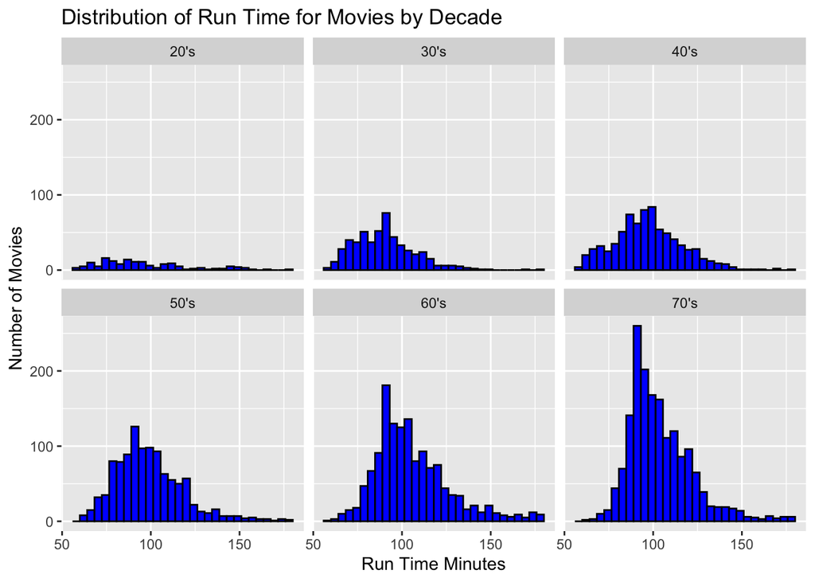

```r
p <- ggplot(a, aes(x = runtimeMinutes)) +
  geom_histogram(color = "black", fill = "blue") +
  ggtitle("Distribution of Run Time for Movies by Decade") +
  ylab("Number of Movies") +
  xlab("Run Time Minutes") +
  facet_wrap(~ decade)
p
```